# Project: Identify Customer Segments

### Step 2.3: Interpret Principal Components

Now that we have our transformed principal components, it's a nice idea to check out the weight of each variable on the first few components to see if they can be interpreted in some fashion.

As a reminder, each principal component is a unit vector that points in the direction of highest variance (after accounting for the variance captured by earlier principal components). The further a weight is from zero, the more the principal component is in the direction of the corresponding feature. If two features have large weights of the same sign (both positive or both negative), then increases in one tend expect to be associated with increases in the other. To contrast, features with different signs can be expected to show a negative correlation: increases in one variable should result in a decrease in the other.

- To investigate the features, you should map each weight to their corresponding feature name, then sort the features according to weight. The most interesting features for each principal component, then, will be those at the beginning and end of the sorted list. Use the data dictionary document to help you understand these most prominent features, their relationships, and what a positive or negative value on the principal component might indicate.
- You should investigate and interpret feature associations from the first three principal components in this substep. To help facilitate this, you should write a function that you can call at any time to print the sorted list of feature weights, for the *i*-th principal component. This might come in handy in the next step of the project, when you interpret the tendencies of the discovered clusters.

```python
# Quick look at the composition of the components.
pca_4.components_
```

```
array([[ 0.24480422, -0.09144836,  0.10687752, ...,  0.00206459,
        -0.22740007,  0.05454451],
       [-0.06943543, -0.15648182,  0.06860794, ...,  0.13261322,
        -0.0094711 ,  0.14971177],
       [-0.04283573, -0.1075217 , -0.01482194, ..., -0.14138208,
         0.09419487,  0.01970535],
       ...,
       [ 0.16597879, -0.09559777, -0.14665033, ...,  0.05839298,
         0.01430583, -0.01613691],
       [-0.02300354, -0.09650829,  0.14704921, ..., -0.01597199,
         0.04116344, -0.07423218],
       [-0.01062804,  0.06253038, -0.00902444, ..., -0.04178485,
         0.01267487,  0.0776691 ]])
```

```python
# Quick look at the value of variance explained by each component
pca_4.explained_variance_ratio_
```

```
array([ 0.00757576,  0.00757576,  0.00757576,  0.00757576,  0.00757576,
        0.00757576,  0.00757576,  0.00757576,  0.00757576,  0.00757576,
        0.00757576,  0.00757576,  0.00757576,  0.00757576,  0.00757576,
        0.00757576,  0.00757576,  0.00757576,  0.00757576,  0.00757576,
        0.00757576])
```

```python
# Create a dataframe of Explained Variance
dimensions = ['PC {}'.format(i) for i in range(1,len(pca_4.components_)+1)]
ratio = pd.DataFrame(pca_4.explained_variance_ratio_,columns = ['EXPLAINED_VARIANCE'])
ratio = ratio.round(4)
ratio.index = dimensions
ratio[:21]
```

|  | EXPLAINED_VARIANCE |
| --- | --- |
| PC 1 | 0.0076 |
| PC 2 | 0.0076 |
| PC 3 | 0.0076 |
| PC 4 | 0.0076 |
| PC 5 | 0.0076 |
| PC 6 | 0.0076 |
| PC 7 | 0.0076 |
| PC 8 | 0.0076 |
| PC 9 | 0.0076 |
| PC 10 | 0.0076 |
| PC 11 | 0.0076 |
| PC 12 | 0.0076 |
| PC 13 | 0.0076 |
| PC 14 | 0.0076 |
| PC 15 | 0.0076 |
| PC 16 | 0.0076 |
| PC 17 | 0.0076 |
| PC 18 | 0.0076 |
| PC 19 | 0.0076 |
| PC 20 | 0.0076 |
| PC 21 | 0.0076 |

```python
# Map weights for the first principal component to corresponding feature names
# and then print the linked values, sorted by weight.
# HINT: Try defining a function here or in a new cell that you can reuse in the
# other cells.

weights = pd.DataFrame(pca_4.components_, columns=header_list)
weights = weights.round(4)
weights.index = dimensions
weights[:5]
```

|  | ALTERSKATEGORIE_GROB | ANREDE_KZ | FINANZ_MINIMALIST | FINANZ_SPARER | FINANZ_VORSORGER | FINANZ_ANLEGER | FINANZ_UNAUFFAELLIGER | FINANZ_HAUSBAUER | GREEN_AVANTGARDE | HEALTH_TYP | ... | CAMEO_DEUG_2015_6.0 | CAMEO_DEUG_2015_7.0 | CAMEO_DEUG_2015_8.0 | CAMEO_DEUG_2015_9.0 | AVANTGARDE | DEKADE | CAMEO_WEALTH | CAMEO_LIFESTAGE | RURAL | GEGEND |
| --- | --- | --- | --- | --- | --- | --- | --- | --- | --- | --- | --- | --- | --- | --- | --- | --- | --- | --- | --- | --- | --- |
| PC 1 | 0.2448 | -0.0914 | 0.1069 | 0.1126 | -0.0028 | 0.0880 | -0.0102 | -0.0536 | -0.0174 | -0.0317 | ... | 0.0825 | -0.0789 | 0.0701 | 0.1338 | 0.1189 | 0.0157 | 0.1861 | 0.0021 | -0.2274 | 0.0545 |
| PC 2 | -0.0694 | -0.1565 | 0.0686 | 0.0368 | -0.0534 | -0.0895 | -0.1039 | -0.1220 | -0.0866 | 0.0465 | ... | 0.1160 | 0.0472 | 0.0583 | -0.0268 | 0.0820 | 0.0434 | -0.1339 | 0.1326 | -0.0095 | 0.1497 |
| PC 3 | -0.0428 | -0.1075 | -0.0148 | 0.1882 | -0.1421 | 0.0040 | 0.0921 | -0.0954 | 0.0042 | -0.1270 | ... | -0.0146 | 0.0100 | 0.0839 | 0.0264 | -0.0492 | 0.0305 | 0.0222 | -0.1414 | 0.0942 | 0.0197 |
| PC 4 | -0.0047 | -0.0276 | -0.0793 | -0.1027 | 0.0684 | 0.1158 | -0.0322 | -0.0255 | -0.0172 | -0.0139 | ... | -0.0331 | -0.0652 | 0.1199 | -0.0325 | -0.0961 | -0.0433 | 0.1196 | 0.0851 | -0.0561 | 0.1133 |
| PC 5 | 0.0462 | -0.0060 | -0.1261 | 0.0457 | 0.1285 | 0.0411 | 0.0990 | -0.1042 | 0.1967 | -0.0949 | ... | 0.0457 | -0.0733 | -0.0710 | 0.1000 | -0.0537 | 0.0328 | -0.1855 | 0.0825 | 0.1646 | 0.1361 |

5 rows × 132 columns

```python
# Combine the 2 dataframes
result = pd.concat([ratio, weights], axis = 1, join_axes=[ratio.index])
result[:3]
```

|  | EXPLAINED_VARIANCE | ALTERSKATEGORIE_GROB | ANREDE_KZ | FINANZ_MINIMALIST | FINANZ_SPARER | FINANZ_VORSORGER | FINANZ_ANLEGER | FINANZ_UNAUFFAELLIGER | FINANZ_HAUSBAUER | GREEN_AVANTGARDE | ... | CAMEO_DEUG_2015_6.0 | CAMEO_DEUG_2015_7.0 | CAMEO_DEUG_2015_8.0 | CAMEO_DEUG_2015_9.0 | AVANTGARDE | DEKADE | CAMEO_WEALTH | CAMEO_LIFESTAGE | RURAL | GEGEND |
| --- | --- | --- | --- | --- | --- | --- | --- | --- | --- | --- | --- | --- | --- | --- | --- | --- | --- | --- | --- | --- | --- |
| PC 1 | 0.0076 | 0.2448 | -0.0914 | 0.1069 | 0.1126 | -0.0028 | 0.0880 | -0.0102 | -0.0536 | -0.0174 | ... | 0.0825 | -0.0789 | 0.0701 | 0.1338 | 0.1189 | 0.0157 | 0.1861 | 0.0021 | -0.2274 | 0.0545 |
| PC 2 | 0.0076 | -0.0694 | -0.1565 | 0.0686 | 0.0368 | -0.0534 | -0.0895 | -0.1039 | -0.1220 | -0.0866 | ... | 0.1160 | 0.0472 | 0.0583 | -0.0268 | 0.0820 | 0.0434 | -0.1339 | 0.1326 | -0.0095 | 0.1497 |
| PC 3 | 0.0076 | -0.0428 | -0.1075 | -0.0148 | 0.1882 | -0.1421 | 0.0040 | 0.0921 | -0.0954 | 0.0042 | ... | -0.0146 | 0.0100 | 0.0839 | 0.0264 | -0.0492 | 0.0305 | 0.0222 | -0.1414 | 0.0942 | 0.0197 |

3 rows × 133 columns

```python
# Function integrating the steps above to be used in later analysis
def show_pca_weights(principal_component,no_of_weights):

    dimensions = ['PC {}'.format(i) for i in range(1,len(pca_4.components_)+1)]

    ratio = pd.DataFrame(pca_4.explained_variance_ratio_,columns = ['EXPLAINED_VARIANCE'])
    ratio = ratio.round(4)
    ratio.index = dimensions

    weights = pd.DataFrame(pca_4.components_, columns=header_list)
    weights = weights.round(4)
    weights.index = dimensions

    result = pd.concat([ratio, weights], axis = 1, join_axes=[ratio.index])
    result[:5]
    print("Principal Component", (principal_component))
    print('-' * 30)
    print(result.iloc[(principal_component)-1].sort_values(ascending=False)[:no_of_weights])
    print('-' * 30)
    print(result.iloc[(principal_component)-1].sort_values()[:no_of_weights])
```

```python
# Analysis of the highest positive and negative weights for the first Principal Componnent
show_pca_weights(1,5)
```

```
Principal Component 1
------------------------------
ALTERSKATEGORIE_GROB    0.2448
WOHNDAUER_2008          0.2057
CAMEO_WEALTH            0.1861
CJT_GESAMTTYP_2.0       0.1751
CJT_GESAMTTYP_4.0       0.1559
Name: PC 1, dtype: float64
------------------------------
RURAL                  -0.2274
NATIONALITAET_KZ_1.0   -0.2264
FINANZTYP_3            -0.2151
LP_FAMILIE_FEIN_9.0    -0.1705
FINANZTYP_2            -0.1620
Name: PC 1, dtype: float64
```

```python
# Analysis of the highest positive and negative weights for the second Principal Componnent
show_pca_weights(2,5)
```

```
Principal Component 2
------------------------------
SHOPPER_TYP_3.0       0.1725
WOHNDAUER_2008        0.1674
KBA05_ANTG3           0.1668
ZABEOTYP_4            0.1591
LP_STATUS_FEIN_7.0    0.1582
Name: PC 2, dtype: float64
------------------------------
ANZ_PERSONEN          -0.2222
CAMEO_DEUG_2015_5.0   -0.1575
ANREDE_KZ             -0.1565
ANZ_TITEL             -0.1554
LP_FAMILIE_FEIN_1.0   -0.1482
Name: PC 2, dtype: float64
```

```python
# Analysis of the highest positive and negative weights for the third Principal Componnent
show_pca_weights(3,5)
```

```
Principal Component 3
------------------------------
NATIONALITAET_KZ_3.0    0.2431
KKK                     0.2027
FINANZ_SPARER           0.1882
ANZ_HAUSHALTE_AKTIV     0.1782
GEBAEUDETYP_RASTER      0.1451
Name: PC 3, dtype: float64
------------------------------
INNENSTADT         -0.2237
RELAT_AB           -0.1605
SEMIO_MAT          -0.1536
FINANZ_VORSORGER   -0.1421
CAMEO_LIFESTAGE    -0.1414
Name: PC 3, dtype: float64
```

```python
# Save checkpoint
azdias_33.to_csv('azdias_checkpoint_3.csv',sep=';',encoding='utf-8',index=False)
```

### Discussion 2.3: Interpret Principal Components

Each component is a combination of the 132 features left after cleaning, with each feature given a weight relative to its importance for a particular principal component. The higher the weight either positive or negative, the more impact the feature has on the calculation of the principal component. What value of weight is important is subjective and depends on the context.

I have taken the 5 highest weights positive and negative to interpret the first 3 principal components, this is an arbitrary decision and I could easily have extended this to 6 or reduced it to only 4 as the weight ratios are close to each other in numeric value.

## Step 3: Clustering

### Step 3.1: Apply Clustering to General Population

You've assessed and cleaned the demographics data, then scaled and transformed them. Now, it's time to see how the data clusters in the principal components space. In this substep, you will apply k-means clustering to the dataset and use the average within-cluster distances from each point to their assigned cluster's centroid to decide on a number of clusters to keep.

- Use sklearn's KMeans class to perform k-means clustering on the PCA-transformed data.
- Then, compute the average difference from each point to its assigned cluster's center. **Hint**: The KMeans object's `.score()` method might be useful here, but note that in sklearn, scores tend to be defined so that larger is better. Try applying it to a small, toy dataset, or use an internet search to help your understanding.
- Perform the above two steps for a number of different cluster counts. You can then see how the average distance decreases with an increasing number of clusters. However, each additional cluster provides a smaller net benefit. Use this fact to select a final number of clusters in which to group the data. **Warning**: because of the large size of the dataset, it can take a long time for the algorithm to resolve. The more clusters to fit, the longer the algorithm will take. You should test for cluster counts through at least 10 clusters to get the full picture, but you shouldn't need to test for a number of clusters above about 30.
- Once you've selected a final number of clusters to use, re-fit a KMeans instance to perform the clustering operation. Make sure that you also obtain the cluster assignments for the general demographics data, since you'll be using them in the final Step 3.3.

```python
# Over a number of different cluster counts...

azdias_4 = pd.read_csv('azdias_checkpoint_3.csv',sep=';')
azdias_4[:1]
    # run k-means clustering on the data and...
def get_kmeans_score(data, center):

    kmeans = KMeans(n_clusters = center, n_init=10, max_iter=300, random_state=42)
    model = kmeans.fit(data)
    score = np.abs(model.score(data))
    return score

score = []
#centroids = [2,4,6,7,8,9,10,11,12,13,14,15,16,18,20,22,25]
centroids = [1,3,6,7,9,12,15,16,18,21,25]

for x in centroids:
    score.append(get_kmeans_score(azdias_4,x))
    print("Current Centroid:",x)

    # compute the average within-cluster distances.
score_ds = pd.Series(score)
centroids_ds = pd.Series(centroids)
score_df = pd.concat([centroids_ds,score_ds],axis=1)
score_df.columns = ['clusters','average_distance']
score_df.set_index('clusters',inplace=True)
score_df['average_distance'] = score_df['average_distance'].round(0)
score_df[:17]
```

```
Current Centroid: 1
Current Centroid: 3
Current Centroid: 6
Current Centroid: 7
Current Centroid: 9
Current Centroid: 12
Current Centroid: 15
Current Centroid: 16
Current Centroid: 18
Current Centroid: 21
Current Centroid: 25
```

| clusters | average_distance |
| --- | --- |
| 1 | 16269582.0 |
| 3 | 15395013.0 |
| 6 | 14595708.0 |
| 7 | 14391647.0 |
| 9 | 14049641.0 |
| 12 | 13631152.0 |
| 15 | 13257368.0 |
| 16 | 13171534.0 |
| 18 | 12940211.0 |
| 21 | 12687909.0 |
| 25 | 12271809.0 |

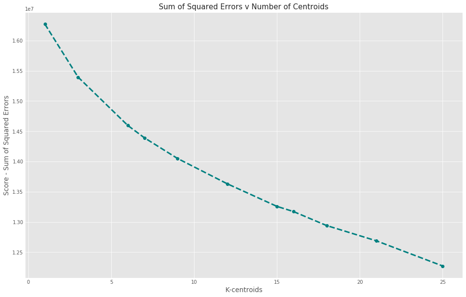

```python
# Investigate the change in within-cluster distance across number of clusters.
# HINT: Use matplotlib's plot function to visualize this relationship.

fig = plt.subplots(figsize=(16,10))
ax = plt.subplot(111)
plt.plot(centroids,score,linestyle='--',linewidth=3,marker='o',color='teal')

ax.set_xlabel('K-centroids', fontsize=13.5)
ax.set_ylabel('Score - Sum of Squared Errors', fontsize=13.5)
plt.title('Sum of Squared Errors v Number of Centroids',fontsize=15);
```

```python
# Re-fit the k-means model with the selected number of clusters and obtain
# cluster predictions for the general population demographics data.

kmeans_10 = KMeans(n_clusters=10, n_init=10, max_iter=300, random_state=42)
population_clusters = kmeans_10.fit_predict(azdias_4)
```

### Discussion 3.1: Apply Clustering to General Population

The first run of K-Means with 132 principal components resulted in almost a straight line with little definition of an "elbow".

However, my final choice of 21 principal components resulted in the plot and table you see above. There is an "elbow", but it is much less defined than with 5 principal components. Possible cluster candidates are 6, 7, 10, 12, and 15 depending if you take a high "elbow" at 6 clusters or low "elbow" at 15 clusters. Again from research on the internet, there doesn't seem to be an agreement on a "correct" location to decide the number of clusters, knowledge of the domain is useful. I also noticed that changing the plotsize and changing the height and width dimensions of the plot affected the perception of where was the best "elbow".

I ran all the clusters mentioned above through the population and customer datasets to be able to make comparisons on the effects of selecting a different number of clusters. In general, the lower number of clusters gave more equal distribution in the population clustering of the dataset, there was less extremes between the clusters, whereas a higher number of clusters resulted in the population clustering having some wide differences between counts allocated to clusters. The customer distribution varied according to the number of clusters.

Once again, due to my inexperience with these techniques, I went for a 'middle' solution and chose 10 clusters which seems to reflect the mid-point in the bend of the "elbow".

### Step 3.2: Apply All Steps to the Customer Data

Now that you have clusters and cluster centers for the general population, it's time to see how the customer data maps on to those clusters. Take care to not confuse this for re-fitting all of the models to the customer data. Instead, you're going to use the fits from the general population to clean, transform, and cluster the customer data. In the last step of the project, you will interpret how the general population fits apply to the customer data.

- Don't forget when loading in the customers data, that it is semicolon (`;`) delimited.
- Apply the same feature wrangling, selection, and engineering steps to the customer demographics using the `clean_data()` function you created earlier. (You can assume that the customer demographics data has similar meaning behind missing data patterns as the general demographics data.)
- Use the sklearn objects from the general demographics data, and apply their transformations to the customers data. That is, you should not be using a `.fit()` or `.fit_transform()` method to re-fit the old objects, nor should you be creating new sklearn objects! Carry the data through the feature scaling, PCA, and clustering steps, obtaining cluster assignments for all of the data in the customer demographics data.

```python
# Load in the customer demographics data.
customers = pd.read_csv('Udacity_CUSTOMERS_Subset.csv',sep=';')
```

```python
# View shape of customer dataset
customers.shape
```

```
(191652, 85)
```

```python
# Quick check of customer dataframe
customers.head()
```

|  | AGER_TYP | ALTERSKATEGORIE_GROB | ANREDE_KZ | CJT_GESAMTTYP | FINANZ_MINIMALIST | FINANZ_SPARER | FINANZ_VORSORGER | FINANZ_ANLEGER | FINANZ_UNAUFFAELLIGER | FINANZ_HAUSBAUER | ... | PLZ8_ANTG1 | PLZ8_ANTG2 | PLZ8_ANTG3 | PLZ8_ANTG4 | PLZ8_BAUMAX | PLZ8_HHZ | PLZ8_GBZ | ARBEIT | ORTSGR_KLS9 | RELAT_AB |
| --- | --- | --- | --- | --- | --- | --- | --- | --- | --- | --- | --- | --- | --- | --- | --- | --- | --- | --- | --- | --- | --- |
| 0 | 2 | 4 | 1 | 5.0 | 5 | 1 | 5 | 1 | 2 | 2 | ... | 3.0 | 3.0 | 1.0 | 0.0 | 1.0 | 5.0 | 5.0 | 1.0 | 2.0 | 1.0 |
| 1 | -1 | 4 | 1 | NaN | 5 | 1 | 5 | 1 | 3 | 2 | ... | NaN | NaN | NaN | NaN | NaN | NaN | NaN | NaN | NaN | NaN |
| 2 | -1 | 4 | 2 | 2.0 | 5 | 1 | 5 | 1 | 4 | 4 | ... | 2.0 | 3.0 | 3.0 | 1.0 | 3.0 | 3.0 | 2.0 | 3.0 | 5.0 | 3.0 |
| 3 | 1 | 4 | 1 | 2.0 | 5 | 1 | 5 | 2 | 1 | 2 | ... | 3.0 | 2.0 | 1.0 | 0.0 | 1.0 | 3.0 | 4.0 | 1.0 | 3.0 | 1.0 |
| 4 | -1 | 3 | 1 | 6.0 | 3 | 1 | 4 | 4 | 5 | 2 | ... | 2.0 | 4.0 | 2.0 | 1.0 | 2.0 | 3.0 | 3.0 | 3.0 | 5.0 | 1.0 |

5 rows × 85 columns

```python
# Apply preprocessing, feature transformation, and clustering from the general
# demographics onto the customer data, obtaining cluster predictions for the
# customer demographics data.

customers_clean = clean_data(customers)

customers_clean.shape

customers_clean[:10]
```

|  | ALTERSKATEGORIE_GROB | ANREDE_KZ | FINANZ_MINIMALIST | FINANZ_SPARER | FINANZ_VORSORGER | FINANZ_ANLEGER | FINANZ_UNAUFFAELLIGER | FINANZ_HAUSBAUER | GREEN_AVANTGARDE | HEALTH_TYP | ... | CAMEO_DEUG_2015_6 | CAMEO_DEUG_2015_7 | CAMEO_DEUG_2015_8 | CAMEO_DEUG_2015_9 | AVANTGARDE | DEKADE | CAMEO_WEALTH | CAMEO_LIFESTAGE | RURAL | GEGEND |
| --- | --- | --- | --- | --- | --- | --- | --- | --- | --- | --- | --- | --- | --- | --- | --- | --- | --- | --- | --- | --- | --- |
| 0 | 4.0 | 1 | 5 | 1 | 5 | 1 | 2 | 2 | 1 | 1.0 | ... | 0 | 0 | 0 | 0 | 1.0 | 2.0 | 5.0 | 3.0 | 1 | 0 |
| 2 | 4.0 | 2 | 5 | 1 | 5 | 1 | 4 | 4 | 1 | 2.0 | ... | 0 | 0 | 0 | 0 | 1.0 | 2.0 | 3.0 | 4.0 | 0 | 2 |
| 3 | 4.0 | 1 | 5 | 1 | 5 | 2 | 1 | 2 | 0 | 2.0 | ... | 0 | 0 | 0 | 0 | 0.0 | 1.0 | 4.0 | 4.0 | 1 | 0 |
| 4 | 3.0 | 1 | 3 | 1 | 4 | 4 | 5 | 2 | 0 | 3.0 | ... | 0 | 1 | 0 | 0 | 0.0 | 4.0 | 2.0 | 1.0 | 0 | 3 |
| 5 | 3.0 | 1 | 5 | 1 | 5 | 1 | 2 | 3 | 1 | 3.0 | ... | 0 | 0 | 0 | 0 | 1.0 | 2.0 | 3.0 | 4.0 | 0 | 1 |
| 6 | 4.0 | 1 | 5 | 1 | 5 | 1 | 1 | 2 | 1 | 2.0 | ... | 0 | 0 | 0 | 0 | 1.0 | 2.0 | 4.0 | 3.0 | 1 | 0 |
| 7 | 4.0 | 1 | 5 | 1 | 5 | 1 | 2 | 2 | 1 | 1.0 | ... | 0 | 0 | 0 | 0 | 1.0 | 2.0 | 5.0 | 5.0 | 0 | 3 |
| 8 | 4.0 | 2 | 2 | 2 | 5 | 1 | 1 | 5 | 0 | 2.0 | ... | 0 | 0 | 0 | 1 | 0.0 | 1.0 | 1.0 | 5.0 | 0 | 4 |
| 9 | 3.0 | 1 | 5 | 2 | 4 | 1 | 3 | 1 | 1 | 3.0 | ... | 0 | 0 | 0 | 0 | 1.0 | 4.0 | 5.0 | 5.0 | 0 | 5 |
| 11 | 4.0 | 1 | 5 | 1 | 5 | 1 | 3 | 2 | 1 | 1.0 | ... | 0 | 0 | 0 | 0 | 1.0 | 2.0 | 5.0 | 4.0 | 0 | 4 |

10 rows × 132 columns

```python
customer_header_list = list(customers_clean.columns.values)
customer_header_list
```

```
['ALTERSKATEGORIE_GROB',
 'ANREDE_KZ',
 'FINANZ_MINIMALIST',
 'FINANZ_SPARER',
 'FINANZ_VORSORGER',
 'FINANZ_ANLEGER',
 'FINANZ_UNAUFFAELLIGER',
 'FINANZ_HAUSBAUER',
 'GREEN_AVANTGARDE',
 'HEALTH_TYP',
 'RETOURTYP_BK_S',
 'SEMIO_SOZ',
 'SEMIO_FAM',
 'SEMIO_REL',
 'SEMIO_MAT',
 'SEMIO_VERT',
 'SEMIO_LUST',
 'SEMIO_ERL',
 'SEMIO_KULT',
 'SEMIO_RAT',
 'SEMIO_KRIT',
 'SEMIO_DOM',
 'SEMIO_KAEM',
 'SEMIO_PFLICHT',
 'SEMIO_TRADV',
 'SOHO_KZ',
 'VERS_TYP',
 'ANZ_PERSONEN',
 'ANZ_TITEL',
 'HH_EINKOMMEN_SCORE',
 'W_KEIT_KIND_HH',
 'WOHNDAUER_2008',
 'ANZ_HAUSHALTE_AKTIV',
 'ANZ_HH_TITEL',
 'KONSUMNAEHE',
 'OST_WEST_KZ',
 'KBA05_ANTG1',
 'KBA05_ANTG2',
 'KBA05_ANTG3',
 'KBA05_ANTG4',
```

[output cut: 77 more lines]

```
 'CAMEO_DEUG_2015_1',
 'CAMEO_DEUG_2015_2',
 'CAMEO_DEUG_2015_3',
 'CAMEO_DEUG_2015_4',
 'CAMEO_DEUG_2015_5',
 'CAMEO_DEUG_2015_6',
 'CAMEO_DEUG_2015_7',
 'CAMEO_DEUG_2015_8',
 'CAMEO_DEUG_2015_9',
 'AVANTGARDE',
 'DEKADE',
 'CAMEO_WEALTH',
 'CAMEO_LIFESTAGE',
 'RURAL',
 'GEGEND']
```

```python
# Check for null values
customers_clean.isnull().any().sum()
```

```
32
```

```python
# Use population imputer to transform customer dataframe
customers_clean = imputer.transform(customers_clean)
customers_clean = pd.DataFrame(customers_clean)
customers_clean.head()
```

|  | 0 | 1 | 2 | 3 | 4 | 5 | 6 | 7 | 8 | 9 | ... | 122 | 123 | 124 | 125 | 126 | 127 | 128 | 129 | 130 | 131 |
| --- | --- | --- | --- | --- | --- | --- | --- | --- | --- | --- | --- | --- | --- | --- | --- | --- | --- | --- | --- | --- | --- |
| 0 | 4.0 | 1.0 | 5.0 | 1.0 | 5.0 | 1.0 | 2.0 | 2.0 | 1.0 | 1.0 | ... | 0.0 | 0.0 | 0.0 | 0.0 | 1.0 | 2.0 | 5.0 | 3.0 | 1.0 | 0.0 |
| 1 | 4.0 | 2.0 | 5.0 | 1.0 | 5.0 | 1.0 | 4.0 | 4.0 | 1.0 | 2.0 | ... | 0.0 | 0.0 | 0.0 | 0.0 | 1.0 | 2.0 | 3.0 | 4.0 | 0.0 | 2.0 |
| 2 | 4.0 | 1.0 | 5.0 | 1.0 | 5.0 | 2.0 | 1.0 | 2.0 | 0.0 | 2.0 | ... | 0.0 | 0.0 | 0.0 | 0.0 | 0.0 | 1.0 | 4.0 | 4.0 | 1.0 | 0.0 |
| 3 | 3.0 | 1.0 | 3.0 | 1.0 | 4.0 | 4.0 | 5.0 | 2.0 | 0.0 | 3.0 | ... | 0.0 | 1.0 | 0.0 | 0.0 | 0.0 | 4.0 | 2.0 | 1.0 | 0.0 | 3.0 |
| 4 | 3.0 | 1.0 | 5.0 | 1.0 | 5.0 | 1.0 | 2.0 | 3.0 | 1.0 | 3.0 | ... | 0.0 | 0.0 | 0.0 | 0.0 | 1.0 | 2.0 | 3.0 | 4.0 | 0.0 | 1.0 |

5 rows × 132 columns

```python
# Check no null values remain
customers_clean.isnull().any().sum()
```

```
0
```

```python
# Apply population scaler to transform customer dataframe
customers_clean = scaler.transform(customers_clean)
customers_clean = pd.DataFrame(customers_clean)
customers_clean.head()
```

|  | 0 | 1 | 2 | 3 | 4 | 5 | 6 | 7 | 8 | 9 | ... | 122 | 123 | 124 | 125 | 126 | 127 | 128 | 129 | 130 | 131 |
| --- | --- | --- | --- | --- | --- | --- | --- | --- | --- | --- | --- | --- | --- | --- | --- | --- | --- | --- | --- | --- | --- |
| 0 | 1.180995 | -1.043381 | 1.415239 | -1.151076 | 1.133590 | -1.247929 | -0.454293 | -0.818216 | 1.882757 | -1.637628 | ... | -0.392968 | -0.330435 | -0.454342 | -0.39952 | 1.882757 | -1.624552 | 1.556065 | 0.092492 | 1.811996 | -1.471874 |
| 1 | 1.180995 | 0.958422 | 1.415239 | -1.151076 | 1.133590 | -1.247929 | 0.981043 | 0.612067 | 1.882757 | -0.315096 | ... | -0.392968 | -0.330435 | -0.454342 | -0.39952 | 1.882757 | -1.624552 | 0.192596 | 0.763676 | -0.551878 | -0.250165 |
| 2 | 1.180995 | -1.043381 | 1.415239 | -1.151076 | 1.133590 | -0.568811 | -1.171961 | -0.818216 | -0.531136 | -0.315096 | ... | -0.392968 | -0.330435 | -0.454342 | -0.39952 | -0.531136 | -2.307192 | 0.874330 | 0.763676 | 1.811996 | -1.471874 |
| 3 | 0.198811 | -1.043381 | -0.036773 | -1.151076 | 0.407498 | 0.789423 | 1.698711 | -0.818216 | -0.531136 | 1.007436 | ... | -0.392968 | 3.026312 | -0.454342 | -0.39952 | -0.531136 | -0.259273 | -0.489138 | -1.249876 | -0.551878 | 0.360689 |
| 4 | 0.198811 | -1.043381 | 1.415239 | -1.151076 | 1.133590 | -1.247929 | -0.454293 | -0.103075 | 1.882757 | 1.007436 | ... | -0.392968 | -0.330435 | -0.454342 | -0.39952 | 1.882757 | -1.624552 | 0.192596 | 0.763676 | -0.551878 | -0.861020 |

5 rows × 132 columns

```python
# Apply population Principal Component transformation on customer dataframe
customers_clean = pca_4.transform(customers_clean)
customers_clean = pd.DataFrame(customers_clean)
customers_clean.head()
```

|  | 0 | 1 | 2 | 3 | 4 | 5 | 6 | 7 | 8 | 9 | ... | 11 | 12 | 13 | 14 | 15 | 16 | 17 | 18 | 19 | 20 |
| --- | --- | --- | --- | --- | --- | --- | --- | --- | --- | --- | --- | --- | --- | --- | --- | --- | --- | --- | --- | --- | --- |
| 0 | -1.322944 | 0.369826 | 0.254484 | 0.603749 | 1.104802 | 1.414331 | 2.050217 | 0.538836 | 0.075372 | -0.616726 | ... | 0.591253 | 0.227190 | -1.208954 | -0.374718 | -1.173440 | -0.515260 | -0.057842 | -0.295475 | 0.856317 | -1.027160 |
| 1 | 0.514673 | -1.228587 | -0.980308 | -0.777674 | 0.385233 | -1.065641 | 0.562527 | -0.729158 | 0.080361 | -0.448946 | ... | 0.006440 | -0.306113 | -0.055778 | -0.619406 | 0.029502 | 1.778859 | 0.830614 | 0.401911 | 0.887221 | -1.049830 |
| 2 | 0.504730 | -0.292977 | -0.433452 | 0.794585 | 0.043493 | -0.118839 | 0.831462 | -0.190385 | -0.285483 | 1.568661 | ... | -0.041100 | -0.017237 | -0.638413 | 0.962047 | -0.152654 | 0.853726 | -0.528153 | 0.730779 | -0.644941 | -0.473053 |
| 3 | -0.604558 | -0.747832 | 0.215893 | 0.989579 | -0.235917 | -1.010837 | -1.302406 | -1.086868 | -0.447208 | -0.078664 | ... | -1.022976 | 0.259554 | 0.102362 | -1.111223 | -0.712316 | 0.748874 | -0.770115 | -0.808404 | -0.372886 | 0.439177 |
| 4 | -0.176419 | 2.334287 | -1.686244 | -0.085830 | -2.535839 | 0.770029 | 0.316129 | -0.884961 | -1.151908 | 0.197888 | ... | -0.135657 | 0.345969 | -0.140824 | 0.065110 | 0.336088 | -0.246120 | 0.223865 | 1.376555 | 0.196089 | -1.798555 |

5 rows × 21 columns

```python
# Apply K-means clustering prediction using fitted algorithm from population
customer_clusters = kmeans_10.predict(customers_clean)
```

```python
# Obtain missing row data for customer dataset
missing_row_data_2 = customers.isnull().sum(axis=1)
customer_rows_deleted = customers[customers.index.isin(missing_row_data_2[missing_row_data_2 > 9].index)]
customer_rows_deleted[:4]
```

|  | AGER_TYP | ALTERSKATEGORIE_GROB | ANREDE_KZ | CJT_GESAMTTYP | FINANZ_MINIMALIST | FINANZ_SPARER | FINANZ_VORSORGER | FINANZ_ANLEGER | FINANZ_UNAUFFAELLIGER | FINANZ_HAUSBAUER | ... | PLZ8_ANTG1 | PLZ8_ANTG2 | PLZ8_ANTG3 | PLZ8_ANTG4 | PLZ8_BAUMAX | PLZ8_HHZ | PLZ8_GBZ | ARBEIT | ORTSGR_KLS9 | RELAT_AB |
| --- | --- | --- | --- | --- | --- | --- | --- | --- | --- | --- | --- | --- | --- | --- | --- | --- | --- | --- | --- | --- | --- |
| 1 | NaN | 4.0 | 1 | NaN | 5 | 1 | 5 | 1 | 3 | 2 | ... | NaN | NaN | NaN | NaN | NaN | NaN | NaN | NaN | NaN | NaN |
| 3 | 1.0 | 4.0 | 1 | 2.0 | 5 | 1 | 5 | 2 | 1 | 2 | ... | 3.0 | 2.0 | 1.0 | 0.0 | 1.0 | 3.0 | 4.0 | 1.0 | 3.0 | 1.0 |
| 10 | NaN | 3.0 | 2 | 5.0 | 4 | 2 | 4 | 4 | 3 | 1 | ... | NaN | NaN | NaN | NaN | NaN | NaN | NaN | NaN | NaN | NaN |
| 20 | NaN | 4.0 | 1 | 6.0 | 5 | 3 | 4 | 2 | 3 | 1 | ... | 4.0 | 1.0 | 0.0 | 0.0 | 1.0 | 3.0 | 4.0 | 4.0 | 6.0 | 5.0 |

4 rows × 85 columns

```python
customer_rows_deleted.shape
```

```
(61179, 85)
```

### Step 3.3: Compare Customer Data to Demographics Data

At this point, you have clustered data based on demographics of the general population of Germany, and seen how the customer data for a mail-order sales company maps onto those demographic clusters. In this final substep, you will compare the two cluster distributions to see where the strongest customer base for the company is.

Consider the proportion of persons in each cluster for the general population, and the proportions for the customers. If we think the company's customer base to be universal, then the cluster assignment proportions should be fairly similar between the two. If there are only particular segments of the population that are interested in the company's products, then we should see a mismatch from one to the other. If there is a higher proportion of persons in a cluster for the customer data compared to the general population (e.g. 5% of persons are assigned to a cluster for the general population, but 15% of the customer data is closest to that cluster's centroid) then that suggests the people in that cluster to be a target audience for the company. On the other hand, the proportion of the data in a cluster being larger in the general population than the customer data (e.g. only 2% of customers closest to a population centroid that captures 6% of the data) suggests that group of persons to be outside of the target demographics.

Take a look at the following points in this step:

- Compute the proportion of data points in each cluster for the general population and the customer data. Visualizations will be useful here: both for the individual dataset proportions, but also to visualize the ratios in cluster representation between groups. Seaborn's [`countplot()`](https://seaborn.pydata.org/generated/seaborn.countplot.html) or [`barplot()`](https://seaborn.pydata.org/generated/seaborn.barplot.html) function could be handy.
  - Recall the analysis you performed in step 1.1.3 of the project, where you separated out certain data points from the dataset if they had more than a specified threshold of missing values. If you found that this group was qualitatively different from the main bulk of the data, you should treat this as an additional data cluster in this analysis. Make sure that you account for the number of data points in this subset, for both the general population and customer datasets, when making your computations!
- Which cluster or clusters are overrepresented in the customer dataset compared to the general population? Select at least one such cluster and infer what kind of people might be represented by that cluster. Use the principal component interpretations from step 2.3 or look at additional components to help you make this inference. Alternatively, you can use the `.inverse_transform()` method of the PCA and StandardScaler objects to transform centroids back to the original data space and interpret the retrieved values directly.
- Perform a similar investigation for the underrepresented clusters. Which cluster or clusters are underrepresented in the customer dataset compared to the general population, and what kinds of people are typified by these clusters?

```python
# Compare the proportion of data in each cluster for the customer data to the
# proportion of data in each cluster for the general population.
customer_clusters = pd.Series(customer_clusters)
cc = customer_clusters.value_counts().sort_index()
cc = pd.Series(cc)
cc
```

```
0    11636
1    25328
2    13174
3     8485
4    11144
5     6111
6    14481
7    22675
8     4820
9    18305
dtype: int64
```

```python
# What kinds of people are part of a cluster that is overrepresented in the
# customer data compared to the general population?
population_clusters = pd.Series(population_clusters)
pc = population_clusters.value_counts().sort_index()
pc = pd.Series(pc)
pc
```

```
0     85227
1     60042
2    103118
3     74688
4     59635
5     73746
6     67601
7     92596
8     69134
9     88956
dtype: int64
```

```python
# What kinds of people are part of a cluster that is underrepresented in the
# customer data compared to the general population?
final_df = pd.concat([pc, cc], axis=1).reset_index()
final_df.columns = ['cluster','population','customer']
final_df
```

|  | cluster | population | customer |
| --- | --- | --- | --- |
| 0 | 0 | 85227 | 11636 |
| 1 | 1 | 60042 | 25328 |
| 2 | 2 | 103118 | 13174 |
| 3 | 3 | 74688 | 8485 |
| 4 | 4 | 59635 | 11144 |
| 5 | 5 | 73746 | 6111 |
| 6 | 6 | 67601 | 14481 |
| 7 | 7 | 92596 | 22675 |
| 8 | 8 | 69134 | 4820 |
| 9 | 9 | 88956 | 18305 |

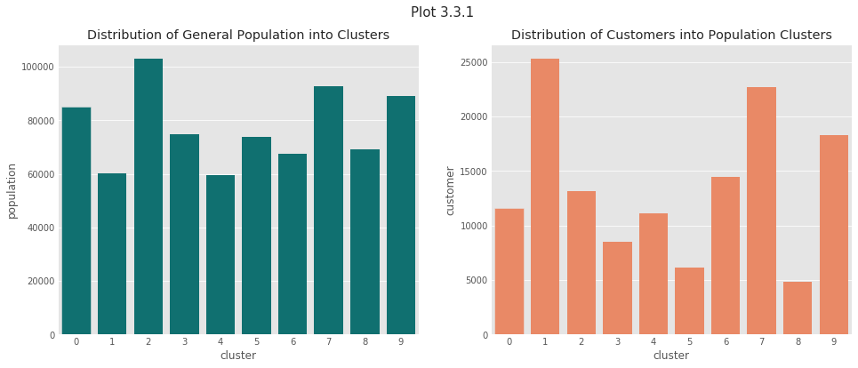

```python
# Visualize dataframe as bar charts
fig = plt.figure(figsize=(16,6))

ax1 = fig.add_subplot(1,2,1)
ax1 = sns.barplot(x='cluster',y='population',color='teal',edgecolor='.9',data=final_df)
plt.title("Distribution of General Population into Clusters")

ax2 = fig.add_subplot(1,2,2)
ax2 = sns.barplot(x='cluster',y='customer',color='coral',edgecolor='.9',data=final_df)
plt.title("Distribution of Customers into Population Clusters")
plt.suptitle("Plot 3.3.1", fontsize=15);
```

```python
# Add ratio and ratio difference for each cluster to the dataframe
final_df['pop_%'] = (final_df['population']/final_df['population'].sum()*100).round(2)
final_df['cust_%'] = (final_df['customer']/final_df['customer'].sum()*100).round(2)
final_df['diff'] = final_df['cust_%'] - final_df['pop_%']
final_df
```

|  | cluster | population | customer | pop_% | cust_% | diff |
| --- | --- | --- | --- | --- | --- | --- |
| 0 | 0 | 85227 | 11636 | 11.00 | 8.55 | -2.45 |
| 1 | 1 | 60042 | 25328 | 7.75 | 18.60 | 10.85 |
| 2 | 2 | 103118 | 13174 | 13.31 | 9.68 | -3.63 |
| 3 | 3 | 74688 | 8485 | 9.64 | 6.23 | -3.41 |
| 4 | 4 | 59635 | 11144 | 7.70 | 8.18 | 0.48 |
| 5 | 5 | 73746 | 6111 | 9.52 | 4.49 | -5.03 |
| 6 | 6 | 67601 | 14481 | 8.73 | 10.64 | 1.91 |
| 7 | 7 | 92596 | 22675 | 11.95 | 16.65 | 4.70 |
| 8 | 8 | 69134 | 4820 | 8.92 | 3.54 | -5.38 |
| 9 | 9 | 88956 | 18305 | 11.48 | 13.44 | 1.96 |

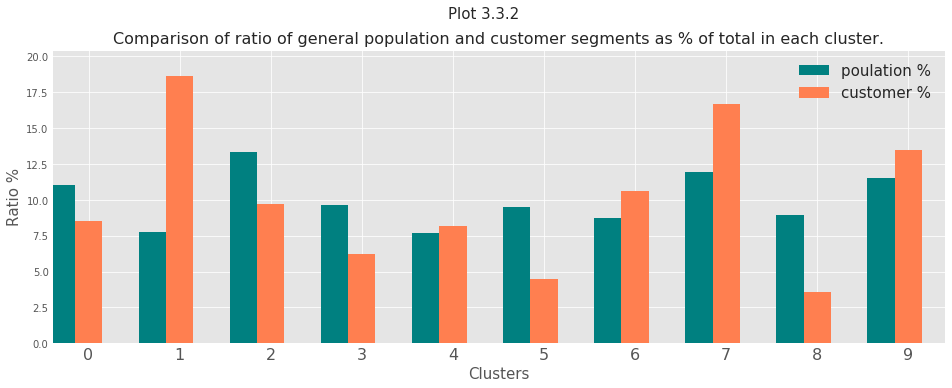

```python
# Visualize ratios for each cluster

fig = plt.figure(figsize=(16,6))

ax = fig.add_subplot(111)

ax = final_df['pop_%'].plot(x=final_df['cluster'], kind='bar',color='teal',width=-0.3, align='edge',position=0)
ax = final_df['cust_%'].plot(kind='bar',color='coral',width = 0.3, align='edge',position=1)

ax.margins(x=0.5,y=0.1)
ax.set_xlabel('Clusters', fontsize=15)
ax.set_ylabel('Ratio %', fontsize=15)
ax.xaxis.set(ticklabels=[0,1,2,3,4,5,6,7,8,9,10,11])
ax.tick_params(axis = 'x', which = 'major', labelsize = 16)
plt.xticks(rotation=360,)

plt.legend(('poulation %', 'customer %'),fontsize=15)
plt.title(('Comparison of ratio of general population and customer segments as % of total in each cluster.')
          ,fontsize=16)

plt.subplots_adjust(bottom=0.2)
plt.suptitle("Plot 3.3.2", fontsize=15)
plt.show()
```